# Measuring biological generality in meta-analysis: a pluralistic approach to heterogeneity quantification and stratification

A step-by-step illustration

# Contributors

Yefeng Yang, Daniel W. A. Noble, Rebecca Spake, Alistair M. Senior, Malgorzata Lagisz, Shinichi Nakagawa

# Update

Last update Nov 2023

# Preface

This step-by-step tutorial is a supplement to our paper targeted at measuring biological generality via meta-analytic heterogeneity.

## Citation

If our paper and tutorial have helped you, please cite the following paper:

> Yefeng Yang, Daniel W. A. Noble, Rebecca Spake, Alistair M. Senior, Malgorzata Lagisz, Shinichi Nakagawa. Measuring biological generality in meta-analysis: a pluralistic approach to heterogeneity quantification and stratification. EcoEvoRxiv, 2023.

## Contact

If you have any questions, mistakes, or bug to report, please contact corresponding authors:

- Dr. Yefeng Yang

Evolution & Ecology Research Centre, EERC School of Biological, Earth and Environmental Sciences, BEES The University of New South Wales, Sydney, Australia

Email: yefeng.yang1@unsw.edu.au

- Professor Shinichi Nakagawa, PhD, FRSN

Evolution & Ecology Research Centre, EERC School of Biological, Earth and Environmental Sciences, BEES The University of New South Wales, Sydney, Australia

Email: s.nakagawa@unsw.edu.au

# Set-up

Our illustrations use R statistical software and existing R packages, which you will first need to download and install.

If you do not have it on your machine, first install `R` ([download](https://cran.r-project.org/)). We recommend also downloading `RStudio`, a popular integrated development environment for coding with `R`, created by a company named posit ([download](https://posit.co/products/open-source/rstudio/)).

After installing `R`, you must install several packages that contain necessary functions for performing the analyses in this tutorial. If the packages are archived in CRAN, use `install.packages()` to install them. For example, to install the `metafor` package (a common meta-analysis package), you can execute `install.packages("metafor")` in the console (bottom left pane of `R Studio`). To install packages that are not on CRAN and archived in Github repositories, execute `devtools::install_github()`. For example, to install `orchaRd` (a meta-analysis visualization package) from Github repository, execute `devtools::install_github("daniel1noble/orchaRd", force = TRUE)`.

The package list is as follows:

```r
# Install and load necessary library
pacman::p_load(tidyverse,
               here,
               DT,
               janitor,
               ggpubr,
               readxl,
               metafor,
               ggplot2,
               ggsignif,
               visdat,
               cowplot,
               patchwork,
               pander,
               rotl,
               ape,
               ggstance,
               ggtree,
               RColorBrewer,
               wesanderson
               )
```

# Custom function

We provide helper functions necessary for our illustrations. To use them, you need to `source` them. You also can paste the source code into the console, and hit “Enter” to let `R` “learn” these custom functions.

```r
source(here("function","custom_function.R"))
```

# Load data and pre-process

```r
#load data
dat_Risely <- read.csv(here("data","Risely_2018_data.csv"))

#subset observations on infection status
status <- subset(dat_Risely, infection.measure=="Infection status") ##subset observations on infection status

#t1 <- status %>% DT::datatable()
```

We also construct the phylogenetic tree to allow for decomposing heterogeneity at both species and phylogeny levels.

```r
#check species we have
#length(unique(status$species_latin)) #25 unique species names, if no misspelling

#find Open Tree Taxonomy (OTT) IDs for each species
taxa <- tnrs_match_names(names = unique(status$species_latin))

#rough check
#length(taxa$unique_name) # 25 unique species names, which is aligned with the species names in the dataset
#tabyl(taxa,approximate_match) # 0 approximate match

#check whether all otts occur in the synthetic tree
ott_in_tree <- ott_id(taxa)[is_in_tree(ott_id(taxa))]  # all good
#length(ott_in_tree) # 25

#make phylo tree
tree <- tol_induced_subtree(ott_ids = ott_id(taxa))
```

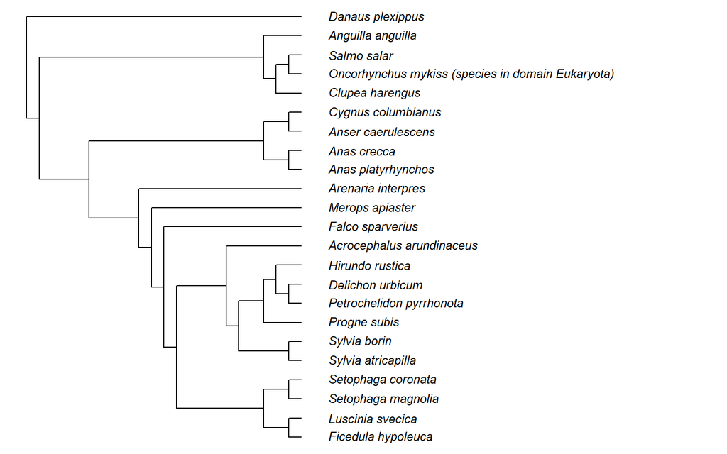

```r
tree$tip.label <- strip_ott_ids(tree$tip.label, remove_underscores = TRUE)

# test whether a tree is binary
#is.binary(tree)

#decapitalise species names to match with the search string names in taxa
status <- status %>% mutate(search_string = tolower(species_latin))

#align data
status <- left_join(status, dplyr::select(taxa, search_string, unique_name, ott_id), by = "search_string")

#create the variables of spp and phylo
status <- status %>% mutate(spp = search_string, phylo = unique_name)


#estimate branch lengths using APE
tree2 <- compute.brlen(tree, method = "Grafen", power = 1)
##create correlation matrix
phylo_corr <- vcv(tree2, corr=TRUE)
plot(tree2, cex = .8, label.offset = .1, no.margin = TRUE)
```

# Fit data

We fit a phylogenetic multilevel model as shown in Equation 19 in the main text to the data. Doing so, we can stratify the heterogeneity at different strata: within-study level (`obs_id`), between-study level (`study_id`), species level (`spp`), and phylogeny level (`phylo`).

$$ES_{[i]} = \mu + u_{species[k]} + u_{phylogeny[k]} + \mu_{between[j]} +
\mu_{within[j]} + e_{[i]}, (19)$$

```r
#unify the name of key variables
dat <- status
dat$obs_id <- 1:nrow(dat)
dat$study_id <- dat$id
# run the model
mod_status <- rma.mv(g, var.g, random = list(~ 1 | obs_id, ~1 | study_id, ~ 1 | spp, ~ 1 | phylo), R = list(phylo = phylo_corr), data = dat)

summary(mod_status)
```

```
Multivariate Meta-Analysis Model (k = 66; method: REML)

  logLik  Deviance       AIC       BIC      AICc
-30.9191   61.8382   71.8382   82.7102   72.8552

Variance Components:

            estim    sqrt  nlvls  fixed    factor    R
sigma^2.1  0.0072  0.0846     66     no    obs_id   no
sigma^2.2  0.0000  0.0000     35     no  study_id   no
sigma^2.3  0.0006  0.0243     23     no       spp   no
sigma^2.4  0.0296  0.1720     23     no     phylo  yes

Test for Heterogeneity:
Q(df = 65) = 356.1658, p-val < .0001

Model Results:

estimate      se     zval    pval    ci.lb    ci.ub
 -0.2134  0.0917  -2.3274  0.0199  -0.3932  -0.0337  *

---
Signif. codes:  0 '***' 0.001 '**' 0.01 '*' 0.05 '.' 0.1 ' ' 1
```

# Heterogeneity quantification and stratification

We quantify and stratify the heterogeneity using the formulas provided in the main text. All functions used are integrated into `orchard` package<sup>1</sup>.

**Typical sampling variance (which captures the statistical noise of the data, but is rarely reported in the current meta-analytic practice):**

```r
sigma2_v(mod_status)
```

```
[1] 0.00131211
```

**Unstandardised heterogeneity metrics $\sigma^2$:**

|  | stratum | sigma2 |
| --- | --- | --- |
| 1 | total | 0.037 |
| 2 | within-study | 0.007 |
| 3 | between-study | 0 |
| 4 | species | 0.001 |
| 5 | phylogeny | 0.03 |

**Variance-standardised heterogeneity metrics $I^2$:**

```r
t3 <- data.frame(stratum = c("total", mod_status$s.names),
           I2 = i2_ml(mod_status)) %>% dfround(1)

t3$stratum <- c("total", "within-study", "between-study", "species", "phylogeny")
rownames(t3) <- NULL

t3 %>% DT::datatable()
```

|  | stratum | I2 |
| --- | --- | --- |
| 1 | total | 96.6 |
| 2 | within-study | 18.5 |
| 3 | between-study | 0 |
| 4 | species | 1.5 |
| 5 | phylogeny | 76.6 |

**Mean-standardised heterogeneity metrics $CV^2$:**

```r
t4 <- data.frame(stratum = c("total", mod_status$s.names),
           CV = cv_ml(mod_status)) %>% dfround(1)

t4$stratum <- c("total", "within-study", "between-study", "species", "phylogeny")
rownames(t4) <- NULL

t4 %>% DT::datatable()
```

|  | stratum | CV |
| --- | --- | --- |
| 1 | total | 0.9 |
| 2 | within-study | 0.4 |
| 3 | between-study | 0 |
| 4 | species | 0.1 |
| 5 | phylogeny | 0.8 |

```r
t5 <- data.frame(stratum = c("total", mod_status$s.names),
           M1 = m1_ml(mod_status)) %>% dfround(1)

t5$stratum <- c("total", "within-study", "between-study", "species", "phylogeny")
rownames(t5) <- NULL

t5 %>% DT::datatable()
```

[output not shown]

**Let’s visualize all heterogeneity measures:**

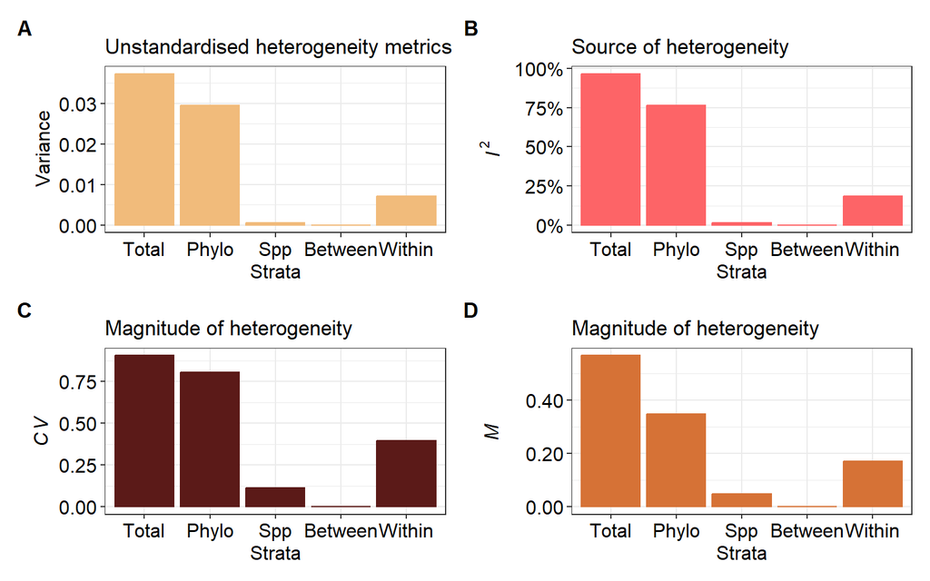

```r
# Visualize heterogeneity
## make dataframe
h_status <- h.calc(mod_status)
h_status$levels <- rownames(h_status)
h_status$levels <- dplyr::recode(h_status$levels, "Total" = "Total",  "obs_id" = "Within",  "study_id" = "Between", "spp" = "Spp", "phylo" = "Phylo")
h_status$levels <- as.factor(h_status$levels)
h_status$levels <- factor(h_status$levels, levels = c("Total", "Phylo", "Spp", "Between", "Within"))

## plot
## sigma
p.sigma <- ggplot(h_status, aes(levels, sigma2s)) +
  geom_col(alpha = 1, color = wes_palette('GrandBudapest1', 4, type = 'discrete')[1], fill = wes_palette('GrandBudapest1', 4, type = 'discrete')[1]) +
  labs(y = expression("Variance"), x = "Strata" , title = "Unstandardised heterogeneity metrics") +
  theme_bw() +
  theme(legend.background = element_blank(),
        axis.text = element_text(size = 12, color = "black"),
        axis.title = element_text(size = 12, color = "black")
        )

# I2
p.I2 <- ggplot(h_status, aes(levels, I2s_Shinichi/100)) +
  geom_col(alpha = 1, color = wes_palette('GrandBudapest1', 4, type = 'discrete')[2], fill = wes_palette('GrandBudapest1', 4, type = 'discrete')[2]) +
  scale_y_continuous(labels = scales::percent_format()
                     ) +
  labs(y = expression(paste(italic(I)[]^2)), x = "Strata" , title = "Source of heterogeneity") +
  theme_bw() +
  theme(legend.background = element_blank(),
        axis.text = element_text(size = 12, color = "black"),
        axis.title = element_text(size = 12, color = "black")
        )

# CV
p.CV <- ggplot(h_status, aes(levels, CVs)) +
  geom_col(alpha = 1, color = wes_palette('GrandBudapest1', 4, type = 'discrete')[3], fill = wes_palette('GrandBudapest1', 4, type = 'discrete')[3]) +
  labs(y = expression(paste(italic(CV)[])), x = "Strata" , title = "Magnitude of heterogeneity") +
  scale_y_continuous(labels = scales::number_format(accuracy = 0.01)) + # https://stackoverflow.com/questions/38722202/how-do-i-change-the-number-of-decimal-places-on-axis-labels-in-ggplot2
  theme_bw() +
  theme(legend.background = element_blank(),
        axis.text = element_text(size = 12, color = "black"),
        axis.title = element_text(size = 12, color = "black")
        )


# M
p.M <- ggplot(h_status, aes(x = levels, y = Ms)) +
  geom_col(alpha = 1, color = wes_palette('GrandBudapest1', 4, type = 'discrete')[4], fill = wes_palette('GrandBudapest1', 4, type = 'discrete')[4]) +
  labs(y = expression(paste(italic(M)[])), x = "Strata" , title = "Magnitude of heterogeneity") +
  scale_y_continuous(labels = scales::number_format(accuracy = 0.01)) + # https://stackoverflow.com/questions/38722202/how-do-i-change-the-number-of-decimal-places-on-axis-labels-in-ggplot2
  theme_bw() +
  theme(legend.background = element_blank(),
        axis.text = element_text(size = 12, color = "black"),
        axis.title = element_text(size = 12, color = "black")
        )




#png(filename = "all.png", width = 9, height = 8, units = "in", type = "windows", res = 400)
p.sigma + p.I2 + p.CV + p.M + plot_layout(ncol =2, nrow = 2) + plot_annotation(tag_levels = "A") & theme(plot.tag = element_text(face = "bold"))
```

```r
#dev.off()
```

# Predictive distributions: visualising heterogeneity

Next, we illustrate how prediction intervals (PIs) combined with ‘prediction distributions’ (PDs) can be used to understand effect size heterogeneity and generality:

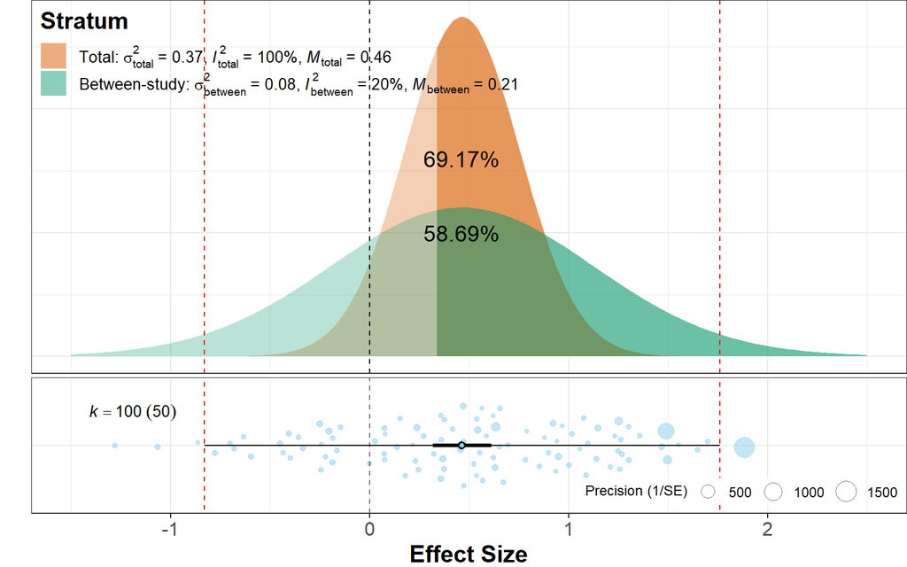

```r
############################################
######## Simulate some meta-analytic data
############################################

set.seed(98)

# Parameters
mu = 0.5                                       # Mean effect size. For example SMD. This is the mean contrast between two groups
tau = 0.1                                      # Between-study variance
obs = 0.6                                      # Within study varaince
n = 50                                       # Number of studies
k = 100                                      # Number of effect sizes
vi = rgamma(k, shape = 0.5, scale = 0.1)       # Effect size sampling variance. Sample from a gamma distribution

# Simulated effect size data
yi = mu + rep(rnorm(n, 0, sd = sqrt(tau)), k/n) + rnorm(k,0, obs) + rnorm(k, 0, sd = sqrt(vi))

# Create data
dat <- data.frame(yi = yi, vi = vi, study = rep(1:n, length = k), within = 1:k)

# Model
mod_sim <- rma.mv(yi, vi, random = list(~ 1 | study, ~1|within), data = dat, method = "REML")


# Get the necessary data
pred_dens_data <- pred_dist_data(mod_sim)[-2,]
pred_dens_data$group[1] <- "Between-study"
pred_dens_data$group[2] <- "Total"

# Calculate what proportion of effect sizes are beyond a biological threshold (in this case SMD = 0.2) for each of the two levels.
pred_dens_data$threshold <- propT_beyond(pred_dens_data, df = mod_sim$k.all - 1, threshold = mod_sim$ci.lb, tail = "above")

mod_resultsdata <- mod_results(mod_sim, mod = "1", group = "study")$mod_table
# Orchardplot
sim_orchard <- orchard_plot(mod_sim, mod = "1", xlab = "Effect Size", group = "study", angle = 45, k.pos = "left") +
            ylim(-1.5, 2.5) +
                    geom_abline(intercept = mod_resultsdata$lowerPR, slope = 0, linetype = 2,  colour = "red") +
                    geom_abline(intercept = mod_resultsdata$upperPR, slope = 0, linetype = 2,  colour = "red") +
                    theme(plot.margin = unit(c(0,0,0,0), 'lines'),
                      axis.title = element_text(size = 15, face = "bold"),
                      axis.text = element_text(size = 12),
                      axis.text.y = element_blank(),
                      axis.ticks.y = element_blank())


# Now create the density plot
    # t distribution
density_between <- data.frame(x = seq(-1.5,2.5,length.out = 1000)) %>%
      mutate(density = c(pred_Tdistri(x, df=mod_sim$k.all-1, m=pred_dens_data$mean[1], sd=pred_dens_data$sd[1]))) %>%
      mutate(group = rep("Between-study", length(x)))
    density_total <- data.frame(x = seq(-1.5,2.5,length.out = 1000)) %>%
      mutate(density = c(pred_Tdistri(x, df=mod_sim$k.all-1, m=pred_dens_data$mean[2], sd=pred_dens_data$sd[2]))) %>%
      mutate(group = rep("Total", length(x)))
    #density_dat <- rbind(density_between, density_total)
    #density_dat$group <- as.factor(density_dat$group)
    #density_dat$group <- factor(density_dat$group, levels = c("Total", "Between-study"))


dens_plot <- ggplot() +
      geom_area(data = density_between, aes(x = x, y = density, fill = "Between-study"),alpha = 0.3) +
      geom_area(data = density_total, aes(x = x, y = density, fill = "total"),alpha = 0.3) +
      scale_fill_manual(values = c("#D95F02", "#1B9E77"), labels = c(bquote("Total:"~paste(italic(sigma)[total]^2)~"= 0.37,"~paste(italic(I)[total]^2)~"= 100%,"~paste(italic(M)[total])~"= 0.46"), bquote("Between-study:"~paste(italic(sigma)[between]^2)~"= 0.08,"~paste(italic(I)[between]^2)~"= 20%,"~paste(italic(M)[between])~"= 0.21"))) +
      stat_function(fun = pred_Tdistri_shaded, args = list(df = mod_sim$k.all - 1, m = pred_dens_data$mean[1], sd = pred_dens_data$sd[1], threshold = mod_sim$ci.lb),
                    geom = "area", fill = "#D95F02", alpha = 0.5) +
      stat_function(fun = pred_Tdistri_shaded, args = list(df = mod_sim$k.all - 1, m = pred_dens_data$mean[2], sd = pred_dens_data$sd[2], threshold = mod_sim$ci.lb),
                    geom = "area", fill = "#1B9E77",  alpha = 0.5) +
      theme_bw() + xlim(-1.5, 2.5) + labs(fill = "Stratum") +
      geom_vline(xintercept = 0, linetype = 2,  colour = "black") +
      geom_vline(xintercept = mod_resultsdata$lowerPR, linetype = 2,  colour = "red") +
      geom_vline(xintercept = mod_resultsdata$upperPR, linetype = 2,  colour = "red") +
      annotate("text", x = pred_dens_data$mean, y = c(0.8, 0.5), label = paste0(pred_dens_data$threshold, "%"), size = 5) +
      theme(legend.position= c(0, 1),
            legend.justification = c(0, 1),
            legend.background = element_blank(),
            legend.text = element_text(size = 10),
            legend.title = element_text(size = 15, face = "bold"),
            axis.text = element_blank(),
            axis.title = element_blank(),
            axis.ticks = element_blank(),
            plot.margin = unit(c(0,0,0,0), 'lines'))

## normal distribution
dens_plot2 <- ggplot(data = data.frame(x=c(-1.5,2.5)), aes(x = x, color = group, fill = group)) +
            pred_distri(pred_dens_data) +
            scale_fill_manual(values = c("#D95F02", "#1B9E77"), labels = c(bquote("Total:"~paste(italic(sigma)[total]^2)~"= 0.37,"~paste(italic(I)[total]^2)~"= 100%,"~paste(italic(M)[total])~"= 0.46"), bquote("Between-study:"~paste(italic(sigma)[between]^2)~"= 0.08,"~paste(italic(I)[between]^2)~"= 20%,"~paste(italic(M)[between])~"= 0.21"))) +
            scale_color_manual(values = c("#D95F02", "#1B9E77"), labels = c(bquote("Total:"~paste(italic(sigma)[total]^2)~"= 0.37,"~paste(italic(I)[total]^2)~"= 100%,"~paste(italic(M)[total])~"= 0.46"), bquote("Between-study:"~paste(italic(sigma)[between]^2)~"= 0.08,"~paste(italic(I)[between]^2)~"= 20%,"~paste(italic(M)[between])~"= 0.21"))) +
            stat_function(fun = pred_distri_shaded, args = list(m = pred_dens_data$mean[1], sd = pred_dens_data$sd[1], threshold = mod_sim$ci.lb),
                    geom = "area", fill = "#1B9E77", color = "#1B9E77", alpha = 0.6) +
            stat_function(fun = pred_distri_shaded, args = list(m = pred_dens_data$mean[2], sd = pred_dens_data$sd[2], threshold = mod_sim$ci.lb),
                    geom = "area", fill = "#D95F02", color = "#D95F02", alpha = 0.6) +
             #theme(legend.text.align = 0) +
                     theme_bw() + xlim(-1.5, 2.5) + labs(fill = "Stratum", color = "Stratum") +
                     geom_vline(xintercept = 0, linetype = 2,  colour = "black") +
                     geom_vline(xintercept = mod_resultsdata$lowerPR, linetype = 2,  colour = "red") +
                      geom_vline(xintercept = mod_resultsdata$upperPR, linetype = 2,  colour = "red") +
                     annotate("text", x = pred_dens_data$mean, y = c(0.8, 0.5), label = paste0(pred_dens_data$threshold, "%"), size = 5) +
                     theme(legend.position= c(0, 1),
                            legend.justification = c(0, 1),
                            legend.background = element_blank(),
                            legend.text = element_text(size = 10),
                            legend.title = element_text(size = 15, face = "bold"),
                            axis.text = element_blank(),
                            axis.title = element_blank(),
                            axis.ticks = element_blank(),
                            plot.margin = unit(c(0,0,0,0), 'lines'))

# Lets try plotting the orchard plot and the density plot together
#ggsave("sim_orchard.png", width = 8, height = 8, dpi = 300)
ggarrange(dens_plot, sim_orchard, heights = c(2, 1),
          ncol = 1, nrow = 2, align = "v", common.legend = FALSE)
```

# License

This documented is licensed under the following license: [CC Attribution-Noncommercial-Share Alike 4.0 International](https://creativecommons.org/licenses/by-nc-sa/4.0/deed.en).

# Software and package versions

**R version 4.0.3 (2020-10-10)**

**Platform:** x86_64-w64-mingw32/x64 (64-bit)

**locale:** _LC_COLLATE=Chinese (Simplified)*China.936*, _LC_CTYPE=Chinese (Simplified)*China.936*, _LC_MONETARY=Chinese (Simplified)*China.936*, *LC_NUMERIC=C* and _LC_TIME=Chinese (Simplified)*China.936*

**attached base packages:** *stats*, *graphics*, *grDevices*, *utils*, *datasets*, *methods* and *base*

**other attached packages:** *extraDistr(v.1.9.1)*, *wesanderson(v.0.3.6)*, *RColorBrewer(v.1.1-3)*, *ggtree(v.3.7.1.001)*, *ggstance(v.0.3.5)*, *ape(v.5.6-1)*, *rotl(v.3.0.11)*, *pander(v.0.6.4)*, *patchwork(v.1.1.1)*, *cowplot(v.1.1.1)*, *visdat(v.0.5.3)*, *ggsignif(v.0.6.3)*, *metafor(v.4.2-0)*, *numDeriv(v.2016.8-1.1)*, *metadat(v.1.2-0)*, *Matrix(v.1.5-3)*, *readxl(v.1.3.1)*, *ggpubr(v.0.4.0)*, *janitor(v.2.1.0)*, *DT(v.0.19)*, *here(v.1.0.1)*, *forcats(v.0.5.2)*, *stringr(v.1.5.0)*, *dplyr(v.1.0.10)*, *purrr(v.0.3.4)*, *readr(v.2.1.2)*, *tidyr(v.1.2.1)*, *tibble(v.3.1.8)*, *ggplot2(v.3.4.4)*, *tidyverse(v.1.3.1)*, *rmdformats(v.1.0.3)* and *knitr(v.1.37)*

**loaded via a namespace (and not attached):** *backports(v.1.2.1)*, *plyr(v.1.8.6)*, *lazyeval(v.0.2.2)*, *splines(v.4.0.3)*, *crosstalk(v.1.1.1)*, *rncl(v.0.8.4)*, *TH.data(v.1.1-0)*, *digest(v.0.6.27)*, *yulab.utils(v.0.0.5)*, *htmltools(v.0.5.2)*, *fansi(v.0.5.0)*, *magrittr(v.2.0.3)*, *tzdb(v.0.1.2)*, *openxlsx(v.4.2.4)*, *modelr(v.0.1.8)*, *sandwich(v.3.0-1)*, *prettyunits(v.1.1.1)*, *colorspace(v.2.0-0)*, *rvest(v.1.0.1)*, *haven(v.2.4.3)*, *xfun(v.0.29)*, *crayon(v.1.4.1)*, *jsonlite(v.1.7.2)*, *survival(v.3.2-7)*, *zoo(v.1.8-9)*, *glue(v.1.6.2)*, *gtable(v.0.3.0)*, *emmeans(v.1.6.3)*, *car(v.3.0-11)*, *rentrez(v.1.2.3)*, *abind(v.1.4-5)*, *scales(v.1.2.1)*, *mvtnorm(v.1.1-3)*, *DBI(v.1.1.1)*, *rstatix(v.0.7.0)*, *Rcpp(v.1.0.8.3)*, *xtable(v.1.8-4)*, *progress(v.1.2.2)*, *gridGraphics(v.0.5-1)*, *tidytree(v.0.4.1)*, *latex2exp(v.0.9.4)*, *foreign(v.0.8-81)*, *htmlwidgets(v.1.5.3)*, *httr(v.1.4.2)*, *ellipsis(v.0.3.2)*, *pkgconfig(v.2.0.3)*, *XML(v.3.99-0.7)*, *farver(v.2.1.0)*, *sass(v.0.4.0)*, *dbplyr(v.2.1.1)*, *utf8(v.1.2.2)*, *ggplotify(v.0.0.9)*, *tidyselect(v.1.2.0)*, *labeling(v.0.4.2)*, *rlang(v.1.1.1)*, *munsell(v.0.5.0)*, *cellranger(v.1.1.0)*, *tools(v.4.0.3)*, *cli(v.3.4.1)*, *generics(v.0.1.0)*, *pacman(v.0.5.1)*, *broom(v.1.0.1)*, *mathjaxr(v.1.2-0)*, *evaluate(v.0.14)*, *fastmap(v.1.1.0)*, *yaml(v.2.2.1)*, *fs(v.1.5.2)*, *zip(v.2.2.0)*, *nlme(v.3.1-151)*, *aplot(v.0.1.8)*, *xml2(v.1.3.2)*, *compiler(v.4.0.3)*, *rstudioapi(v.0.13)*, *beeswarm(v.0.4.0)*, *curl(v.4.3.2)*, *reprex(v.2.0.1)*, *treeio(v.1.14.4)*, *bslib(v.0.3.0)*, *stringi(v.1.7.4)*, *highr(v.0.9)*, *lattice(v.0.20-41)*, *vctrs(v.0.5.0)*, *pillar(v.1.8.1)*, *lifecycle(v.1.0.3)*, *jquerylib(v.0.1.4)*, *estimability(v.1.3)*, *data.table(v.1.14.0)*, *R6(v.2.5.1)*, *bookdown(v.0.24)*, *rio(v.0.5.29)*, *vipor(v.0.4.5)*, *codetools(v.0.2-18)*, *MASS(v.7.3-54)*, *assertthat(v.0.2.1)*, *rprojroot(v.2.0.2)*, *withr(v.2.5.0)*, *multcomp(v.1.4-17)*, *parallel(v.4.0.3)*, *hms(v.1.1.0)*, *grid(v.4.0.3)*, *ggfun(v.0.0.8)*, *coda(v.0.19-4)*, *rmarkdown(v.2.11)*, *snakecase(v.0.11.0)*, *carData(v.3.0-4)*, *lubridate(v.1.7.10)* and *ggbeeswarm(v.0.6.0)*

# References

1.

Nakagawa, S. *et al.* The orchard plot: Cultivating a forest plot for use in ecology, evolution, and beyond. *Research Synthesis Methods* **12**, 4–12 (2021).